# Part A: CIFAR-10 Image Generation with AC-GAN

- Tan Yu Hoe
- 2026409
- DAAA/FT/2B/04

## Motivation

This notebook will be focused on constructing Generative Adverserarial Network while incorporating elements of an Auxiliary Classifier into the network, with expectations of producing better quality images of the CIFAR-10 Dataset compared to a CGAN.

```python
# DL modules
import tensorflow as tf
from tensorflow import keras
from tensorflow.keras.layers import *
from tensorflow.keras import Sequential, Model
import keras.backend as K
from tensorflow.keras.initializers import RandomNormal
! pip install tensorflow_addons
from tensorflow_addons.layers import SpectralNormalization
from tensorflow.keras.utils import to_categorical, plot_model
from tensorflow.keras import backend

# relevent libraries
import numpy as np
import matplotlib.pyplot as plt
import seaborn as sns
import pandas as pd
from tqdm.notebook import tqdm
import os

## matplotlib stylings
plt.rcParams['figure.figsize'] = 12, 8
```

```
     |████████████████████████████████| 1.1 MB 8.6 MB/s
```

## Training on a Tesla P100-PCIE-16GB

There are quite a lot of limitation of using my `NVIDIA GeForce GTX 1050` to trian the model, in terms of training time. Due to my insufficient hardware capability, I decided to switch over to Google Colab where there is a `Tesla P100` available for me, which provided me the resources to train a deeper neural network.

! Important Note: Make sure that you have Tensorflow-GPU, CUDA, and cuDNN enabled before running this notebook.

```
pip install tensorflow cudatoolkit=10.2 cudnn
```

```python
# CPU information
! lscpu
# GPU information
! nvidia-smi
```

```
Architecture:        x86_64
CPU op-mode(s):      32-bit, 64-bit
Byte Order:          Little Endian
CPU(s):              4
On-line CPU(s) list: 0-3
Thread(s) per core:  2
Core(s) per socket:  2
Socket(s):           1
NUMA node(s):        1
Vendor ID:           GenuineIntel
CPU family:          6
Model:               79
Model name:          Intel(R) Xeon(R) CPU @ 2.20GHz
Stepping:            0
CPU MHz:             2199.998
BogoMIPS:            4399.99
Hypervisor vendor:   KVM
Virtualization type: full
L1d cache:           32K
L1i cache:           32K
L2 cache:            256K
L3 cache:            56320K
NUMA node0 CPU(s):   0-3
Flags:               fpu vme de pse tsc msr pae mce cx8 apic sep mtrr pge mca cmov pat pse36 clflush mmx fxsr sse sse2 ss ht syscall nx pdpe1gb rdtscp lm constant_tsc rep_good nopl xtopology nonstop_tsc cpuid tsc_known_freq pni pclmulqdq ssse3 fma cx16 pcid sse4_1 sse4_2 x2apic movbe popcnt aes xsav…
Wed Jan 26 14:04:06 2022
+-----------------------------------------------------------------------------+
| NVIDIA-SMI 495.46       Driver Version: 460.32.03    CUDA Version: 11.2     |
|-------------------------------+----------------------+----------------------+
| GPU  Name        Persistence-M| Bus-Id        Disp.A | Volatile Uncorr. ECC |
| Fan  Temp  Perf  Pwr:Usage/Cap|         Memory-Usage | GPU-Util  Compute M. |
|                               |                      |               MIG M. |
|===============================+======================+======================|
|   0  Tesla P100-PCIE...  Off  | 00000000:00:04.0 Off |                    0 |
| N/A   38C    P0    27W / 250W |      0MiB / 16280MiB |      0%      Default |
|                               |                      |                  N/A |
+-------------------------------+----------------------+----------------------+

+-----------------------------------------------------------------------------+
| Processes:                                                                  |
|  GPU   GI   CI        PID   Type   Process name                  GPU Memory |
|        ID   ID                                                   Usage      |
|=============================================================================|
|  No running processes found                                                 |
+-----------------------------------------------------------------------------+
```

```python
# CUFA information
from tensorflow.python.client import device_lib
print(device_lib.list_local_devices())
```

```
[name: "/device:CPU:0"
device_type: "CPU"
memory_limit: 268435456
locality {
}
incarnation: 11716091515709480221
xla_global_id: -1
, name: "/device:GPU:0"
device_type: "GPU"
memory_limit: 16154099712
locality {
  bus_id: 1
  links {
  }
}
incarnation: 17933116495990165129
physical_device_desc: "device: 0, name: Tesla P100-PCIE-16GB, pci bus id: 0000:00:04.0, compute capability: 6.0"
xla_global_id: 416903419
]
```

## Metadata

Each image is 32 pixels in height, 32 pixels in width and 3 colour channels (RGB), for a total of 3072 pixels in total. Each pixel contains an integer value, between 0 and 255. There are a total of 10 classes within the dataset, the classes are represented as:

| Label | Class | Label | Class |
| --- | --- | --- | --- |
| 0 | airplane | 5 | dog |
| 1 | automobile | 6 | frog |
| 2 | bird | 7 | horse |
| 3 | cat | 8 | ship |
| 4 | deer | 9 | truck |

```python
# import dataset
(x_train, y_train), (x_test, y_test) = tf.keras.datasets.cifar10.load_data()

classes = {
    0: 'Airplane',  1: 'Automobile',
    2: 'Bird',      3: 'Cat',
    4: 'Deer',      5: 'Dog',
    6: 'Frog',      7: 'Horse',
    8: 'Ship',      9: 'Truck'
}

y_train = y_train.reshape(-1)
y_test  = y_test.reshape(-1)

print('Dataset Loaded')
```

```
Downloading data from https://www.cs.toronto.edu/~kriz/cifar-10-python.tar.gz
Dataset Loaded
```

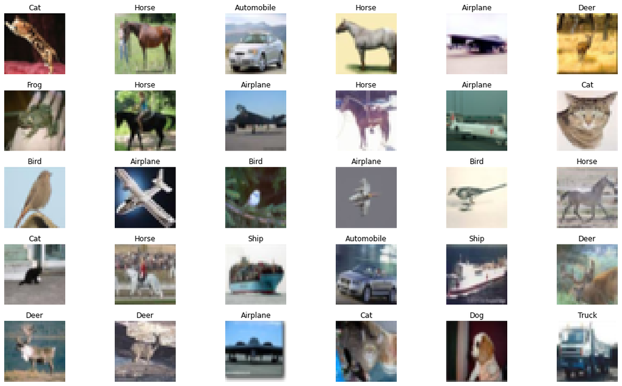

```python
# randomly samples 30 images and plot them out; CLT states 30 samples would be enough
fig = plt.figure(figsize=(16, 9), tight_layout=True)
for i in tqdm(range(30), total=30, desc='Display 30 Images'):
    rand_idx = np.random.randint(0, len(x_train))
    ax = fig.add_subplot(5, 6, i+1)
    ax.imshow(x_train[rand_idx])
    ax.set_title('{}'.format(classes[np.squeeze(y_train)[rand_idx]]))
    ax.axis('off')
plt.show()
```

## Feature Engineering

> Essentially, this section is purposed for preparing the data before feeding it into the model. This is done to increase data quality for increased performance in training.
- Pixel Normalization / Rescaling

$$X' = a + \frac{(X - X_{min})(b - a)}{X_{max} - X_{min}} = -1 + \frac{(X - 0)(1 - (-1))}{255 - 0} = -1 + \frac{X}{127.5}$$

where $X$ represents the pixel intensity values, $b$ is the upper bound of the pre-defined range, $a$ is the lower bound of the pre-defined range.

For Generative Adverserial Networks, it is recommended to use hyperbolic tangent `tanh` activation function in the output layer from the generator model. Given the saturating activation function provides an output range of $[-1, 1]$, it would be recommended to scale down the image to a range $[-1, 1]$.

- One-Hot Encoding aka Categorical Encoding

In conditional GAN, the adversarial network learns to associate the generated images with the allocated labels. In order to express this association in a neural network, one-hot encoding would be required such that each node in the input layer represents one class.

```python
# preprocessing function on images and labels
def preprocessing_func(x, y):
    # pixel normalization
    x = x.astype('float32')
    x /= 127.5
    x -= 1

    y = to_categorical(y=y, num_classes=10)

    return x, y

x_train, y_train = preprocessing_func(x_train, y_train)
x_test, y_test = preprocessing_func(x_test, y_test)

for i in [x_train, y_train, x_test, y_test]:
    print("Shape:", i.shape)
    print("Data Type:", i.dtype)
    print("Class:", type(i))
    print('Max Value:', i.max())
    print('Min Value:', i.min())
    print("---")
```

```
Shape: (50000, 32, 32, 3)
Data Type: float32
Class: <class 'numpy.ndarray'>
Max Value: 1.0
Min Value: -1.0
---
Shape: (50000, 10)
Data Type: float32
Class: <class 'numpy.ndarray'>
Max Value: 1.0
Min Value: 0.0
---
Shape: (10000, 32, 32, 3)
Data Type: float32
Class: <class 'numpy.ndarray'>
Max Value: 1.0
Min Value: -1.0
---
Shape: (10000, 10)
Data Type: float32
Class: <class 'numpy.ndarray'>
Max Value: 1.0
Min Value: 0.0
---
```

# Auxiliary Classifier Generative Adversarial Network

Auxiliary Classifier Generative Adversarial Network, or ACGAN in short, follows a similar architecture to a Conditional GAN. In fact, I've only added less than 10 lines of code for this implementation. There are two main difference between the two architectures - the discriminator produces two outputs and an auxiliary loss function is included in the training process.

[output not shown]

```python
# Hyperparameters and Constants
latent_dim = 128
channels = 3
nclasses = 10
img_shape = (32, 32, 3)
discriminator_in_channels = 10 + 3
```

## Conditional Generator

A regular generator in a GAN architecture takes in a latent noise vector $z$ and performs an upscaling operation to output a synthetic image $G(z)$, similar to training data used. In a conditional generator, it takes in two inputs instead - a latent vector $z$ and a condition $y$, where condition represents classes. The output of a conditional generator would produce a conditioned image $G(z|y)$, where the image should look similar to the class it belongs to.

```python
# latent noise vector z
z = Input(shape=(128,), name="Latent_Noise_Vector_z")

# conditions y
conditions = Input(shape=(10,), name='Conditions_y')

# Generator network
merged_layer = Concatenate()([z, conditions])

# FC: 2x2x512
generator = Dense(2*2*512, activation='relu')(merged_layer)
generator = BatchNormalization(momentum=0.9)(generator)
generator = LeakyReLU(alpha=0.1)(generator)
generator = Reshape((2, 2, 512))(generator)

base_generator = Sequential([
    # Conv 1: 4x4x256
    Conv2DTranspose(256, kernel_size=4, strides=2, padding='same'),
    BatchNormalization(momentum=0.9),
    LeakyReLU(alpha=0.1),
    # Conv 2: 8x8x128
    Conv2DTranspose(128, kernel_size=4, strides=2, padding='same'),
    BatchNormalization(momentum=0.9),
    LeakyReLU(alpha=0.1),
    # Conv 3: 16x16x64
    Conv2DTranspose(64, kernel_size=4, strides=2, padding='same'),
    BatchNormalization(momentum=0.9),
    LeakyReLU(alpha=0.1),
], name='Base_Generator')
generator = base_generator(generator)

# Conv 4: 32x32x3
generator = Conv2DTranspose(3, kernel_size=4, strides=2, padding='same', activation='tanh', name='Output_Layer')(generator)

generator = Model(inputs=[z, conditions], outputs=generator, name='generator')

generator.summary()
```

```
Model: "generator"
__________________________________________________________________________________________________
 Layer (type)                   Output Shape         Param #     Connected to
==================================================================================================
 Latent_Noise_Vector_z (InputLa  [(None, 128)]       0           []
 yer)

 Conditions_y (InputLayer)      [(None, 10)]         0           []

 concatenate (Concatenate)      (None, 138)          0           ['Latent_Noise_Vector_z[0][0]',
                                                                  'Conditions_y[0][0]']

 dense (Dense)                  (None, 2048)         284672      ['concatenate[0][0]']

 batch_normalization (BatchNorm  (None, 2048)        8192        ['dense[0][0]']
 alization)

 leaky_re_lu (LeakyReLU)        (None, 2048)         0           ['batch_normalization[0][0]']

 reshape (Reshape)              (None, 2, 2, 512)    0           ['leaky_re_lu[0][0]']

 Base_Generator (Sequential)    (None, 16, 16, 64)   2754752     ['reshape[0][0]']

 Output_Layer (Conv2DTranspose)  (None, 32, 32, 3)   3075        ['Base_Generator[0][0]']

==================================================================================================
Total params: 3,050,691
Trainable params: 3,045,699
Non-trainable params: 4,992
__________________________________________________________________________________________________
```

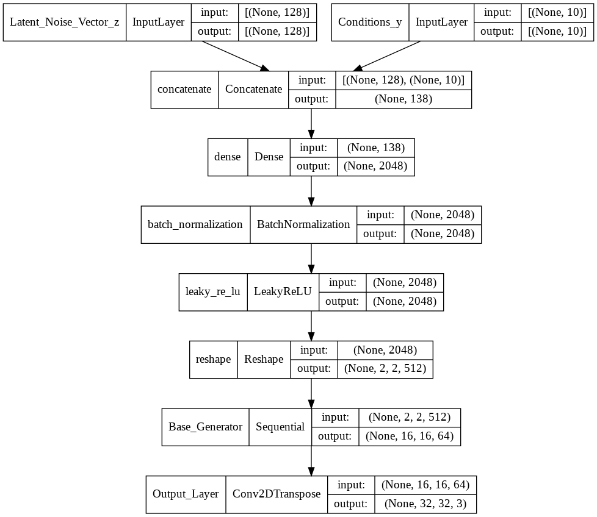

```python
# visualise model
plot_model(generator, show_shapes=True)
```

## Auxiliary Classifier Discriminator

In typical CGAN architectures, the discriminator takes in two inputs - a real image $G(z|y)$ or $x|y$ and its condition $y$ , and provides an output that indicates the discrimination of an image, $1$ to represent a real image and $0$ to represent a fake image.

Whereas in an ACGAN architecture, the discriminator has two output - a disciminator and a classifier. The discrimination will output a probability to indicate realness of an image, denoted as either $D(G(z|y)$ or $D(x|y)$. The classifier would output a set of condition probailities to classify the image, denoted as $\hat{y}$.

This slightly changes the objective of the GAN. Instead of reducing the loss (error) between a real image $D(x|y)$ and a synthetic image produced by a GAN $D(G(z|y))$, it also has to reduce the loss between the conditions $y$ and the predicted conditions $\hat{y}$; hence the term **"Auxiliary Classifier"**.

```python
# input image
img_input = Input(shape=(x_train[0].shape), name='Image_Input')

# conditions y
conditions = Input(shape=(10,), name='Conditions_y')

base_discriminator = Sequential([
    # 16x16x64
    Conv2D(64, kernel_size=4, strides=2, padding='same'),
    BatchNormalization(momentum=0.9),
    LeakyReLU(alpha=0.1),
    # 8x8x128
    Conv2D(128, kernel_size=4, strides=2, padding='same'),
    BatchNormalization(momentum=0.9),
    LeakyReLU(alpha=0.1),
    # 4x4x256
    Conv2D(256, kernel_size=4, strides=2, padding='same'),
    BatchNormalization(momentum=0.9),
    LeakyReLU(alpha=0.1),
    # 2x2x512
    Conv2D(512, kernel_size=4, strides=2, padding='same'),
    BatchNormalization(momentum=0.9),
    LeakyReLU(alpha=0.1),
], name='Base_Discriminator')
discriminator = base_discriminator(img_input)

# Feature Extraction via GAP: 512
discriminator = GlobalAveragePooling2D()(discriminator)

# Concatenate - combine with conditions y
merged_layer = Concatenate()([discriminator, conditions])
discriminator = Dense(512, activation='relu')(merged_layer)

# Output
Disc_Output_Layer = Dense(1, activation='sigmoid', name='Disc_Output_Layer')(discriminator)
Aux_Output_Layer = Dense(10, activation='softmax', name='Aux_Output_Layer')(discriminator)

discriminator = Model(inputs=[img_input, conditions], outputs=[Disc_Output_Layer, Aux_Output_Layer], name='discriminator')

discriminator.summary()
```

```
Model: "discriminator"
__________________________________________________________________________________________________
 Layer (type)                   Output Shape         Param #     Connected to
==================================================================================================
 Image_Input (InputLayer)       [(None, 32, 32, 3)]  0           []

 Base_Discriminator (Sequential  (None, 2, 2, 512)   2760384     ['Image_Input[0][0]']
 )

 global_average_pooling2d (Glob  (None, 512)         0           ['Base_Discriminator[0][0]']
 alAveragePooling2D)

 Conditions_y (InputLayer)      [(None, 10)]         0           []

 concatenate_1 (Concatenate)    (None, 522)          0           ['global_average_pooling2d[0][0]'
                                                                 , 'Conditions_y[0][0]']

 dense_1 (Dense)                (None, 512)          267776      ['concatenate_1[0][0]']

 Disc_Output_Layer (Dense)      (None, 1)            513         ['dense_1[0][0]']

 Aux_Output_Layer (Dense)       (None, 10)           5130        ['dense_1[0][0]']

==================================================================================================
Total params: 3,033,803
Trainable params: 3,031,883
Non-trainable params: 1,920
__________________________________________________________________________________________________
```

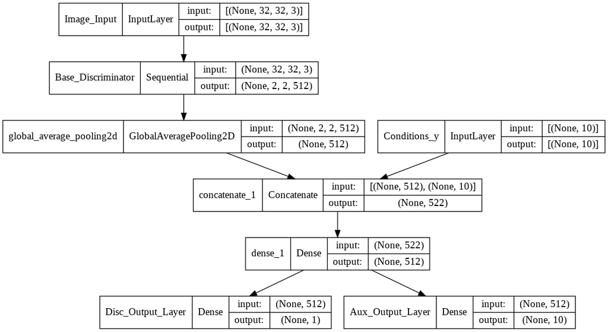

```python
# visualise model
plot_model(discriminator, show_shapes=True)
```

## Training Process

There is an important concept for ACGAN during the training process. Instead of having one loss function, there is two loss function for different purposes.

- Discriminator Loss, aka `disc_loss`
- Auxiliary Classifier Loss, aka `aux_loss`

The loss functions are then added together as a single loss before weights update.

```
real_loss = disc_loss + aux_loss
```

```python
## Code Source: https://github.com/keras-team/keras-io/blob/master/examples/generative/conditional_gan.py
class ConditionalGAN(tf.keras.Model):
    def __init__(self, discriminator, generator, latent_dim):
        super(ConditionalGAN, self).__init__()
        self.discriminator = discriminator
        self.generator = generator
        self.latent_dim = latent_dim
        self.gen_loss_tracker = tf.keras.metrics.Mean(name="generator_loss")
        self.disc_loss_tracker = tf.keras.metrics.Mean(name="discriminator_loss")
        self.d_xy_tracker = tf.keras.metrics.Mean(name='Mean D(x|y)')
        self.d_g_zy_tracker = tf.keras.metrics.Mean(name='Mean D(G(z|y))')
        self.kl = tf.keras.metrics.KLDivergence()

    def compile(self, d_optimizer, g_optimizer, disc_loss_fn, aux_loss_fn):
        super(ConditionalGAN, self).compile()
        self.d_optimizer = d_optimizer
        self.g_optimizer = g_optimizer
        self.disc_loss_fn = disc_loss_fn
        self.aux_loss_fn = aux_loss_fn

    def train_step(self, data):
        ### TRAINING DISCRIMINATOR ###
        # Unpack the data.
        real_images, condition = data

        # Sample for latent noise vector z
        batch_size = tf.shape(real_images)[0]
        latent_noise_vector = tf.random.normal(shape=(batch_size, self.latent_dim))

        # Maps the noise latent vector and labels to generate fake images.
        generated_images = self.generator([latent_noise_vector, condition])

        # Combine with real images
        combined_images = tf.concat([generated_images, real_images], axis=0)
        combined_condition = tf.concat([condition, condition], axis=0)

        # Discrimination
        labels = tf.concat(
            [tf.zeros((batch_size, 1)), tf.ones((batch_size, 1))], axis=0
        )

        # Train the discriminator.
        with tf.GradientTape() as tape:
            disc_output, aux_output = self.discriminator([combined_images, combined_condition])
            disc_d_loss = self.disc_loss_fn(labels, disc_output)
            aux_d_loss = self.aux_loss_fn(combined_condition, aux_output)
            d_loss = disc_d_loss + aux_d_loss
        grads = tape.gradient(d_loss, self.discriminator.trainable_weights)
        self.d_optimizer.apply_gradients(
            zip(grads, self.discriminator.trainable_weights)
        )

        # Computing D(x|y)
        d_xy = tf.math.reduce_mean(disc_output)

        ### TRAINING GENRATOR ###
        latent_noise_vector = tf.random.normal(shape=(batch_size, self.latent_dim))

        # Assemble labels that say "all real images".
        misleading_labels = tf.ones((batch_size, 1))

        # Train the Generator
        with tf.GradientTape() as tape:
            fake_images = self.generator([latent_noise_vector, condition])
            disc_output, aux_output = self.discriminator([fake_images, condition])
            disc_g_loss = self.disc_loss_fn(misleading_labels, disc_output)
            aux_g_loss = self.aux_loss_fn(condition, aux_output)
            g_loss = disc_g_loss + aux_g_loss
        grads = tape.gradient(g_loss, self.generator.trainable_weights)
        self.g_optimizer.apply_gradients(zip(grads, self.generator.trainable_weights))

        # Computing D(G(z|y))
        d_g_zy = tf.math.reduce_mean(disc_output)

        # Monitor loss and metrics.
        self.gen_loss_tracker.update_state(g_loss)
        self.disc_loss_tracker.update_state(d_loss)
        self.d_xy_tracker.update_state(d_xy)
        self.d_g_zy_tracker.update_state(d_g_zy)
        self.kl.update_state(real_images, fake_images)

        return {
            "d_loss": self.disc_loss_tracker.result(),
            "g_loss": self.gen_loss_tracker.result(),
            "D(x|y)": self.d_xy_tracker.result(),
            "D(G(z|y))": self.d_g_zy_tracker.result(),
            "KL Divergence": self.kl.result(),
        }
```

## Callback Functions

```python
# Custom callback to display generated images every n epochs and after training
class GANMonitor(keras.callbacks.Callback):
    # class GANMontor
    # - num_img: number of images generated using matplotlib figure
    # - latent_dim: dimensions of noise latent vector passed into the generator
    # - patience: number of epochs to generate images
    # - vmin: minumum scaling factor, a
    # - vmax: maximum scaling factor, b
    # NOTE: only compatible with the GAN class I've set up
    def __init__(self, num_img=20, latent_dim=128, patience=10, vmin=0, vmax=1):
        self.num_img = num_img
        self.latent_dim = latent_dim
        self.patience = patience
        self.vmin = vmin
        self.vmax = vmax

        # making the latent vec
        self.latent_noise_vector = tf.random.normal(shape=(self.num_img, self.latent_dim))
        self.conditions = to_categorical([0, 1, 2, 3, 4, 5, 6, 7, 8, 9,
                                 0, 1, 2, 3, 4, 5, 6, 7, 8, 9])

    # method to generate images and display them as matplotlib figure
    def generate_plot(self):
        # Generate Images
        generated_images = self.model.generator.predict([self.latent_noise_vector, self.conditions])

        # Normalise Image from [vmin, vmax] to [0, 1]
        generated_images -= self.vmin
        generated_images /= (self.vmax - self.vmin)

        # Generate Matplotlib Figure
        row_size = np.ceil(self.num_img/5)
        fig = plt.figure(figsize=(10, 2*row_size), tight_layout=True)
        for i in range(self.num_img):
            ax = fig.add_subplot(row_size, 5, i+1)
            ax.imshow(generated_images[i])
            ax.set_title(classes[i%10])
            ax.axis('off')
        plt.show()

    # method to save generator's weights
    def save_weights(self, epoch=None):
        try:
            if epoch != None:
                name='generator-epoch-{}.h5'.format(epoch)
                print('Generator Checkpoint - {}'.format(name))
                self.model.generator.save_weights(
                    filepath=name,
                    save_format='h5'
                )
        except Exception as e:
            print(e)

    # generate a plot every n epochs
    def on_epoch_begin(self, epoch, logs=None):
        if epoch % self.patience == 0:
            self.generate_plot()
            self.save_weights(epoch)

    # generate a plot after training
    def on_train_end(self, epoch, logs=None):
        self.generate_plot()
        self.save_weights('Full Train')
```

```python
# List of Callback Functions
callbacks = [
    GANMonitor(num_img=20, latent_dim=128, patience=5, vmin=-1, vmax=1),
]
```

## ACGAN Training

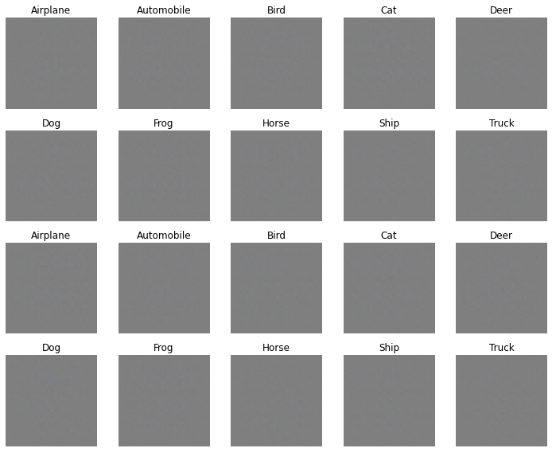

```
Generator Checkpoint - generator-epoch-0.h5
```

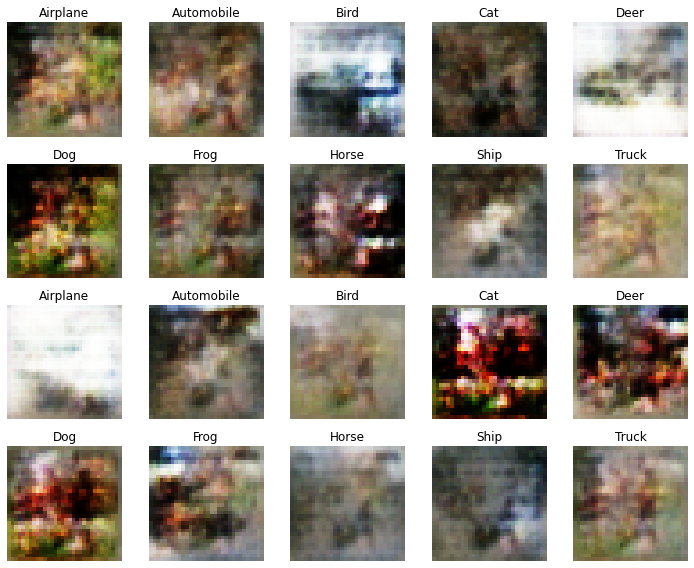

```
Generator Checkpoint - generator-epoch-5.h5
```

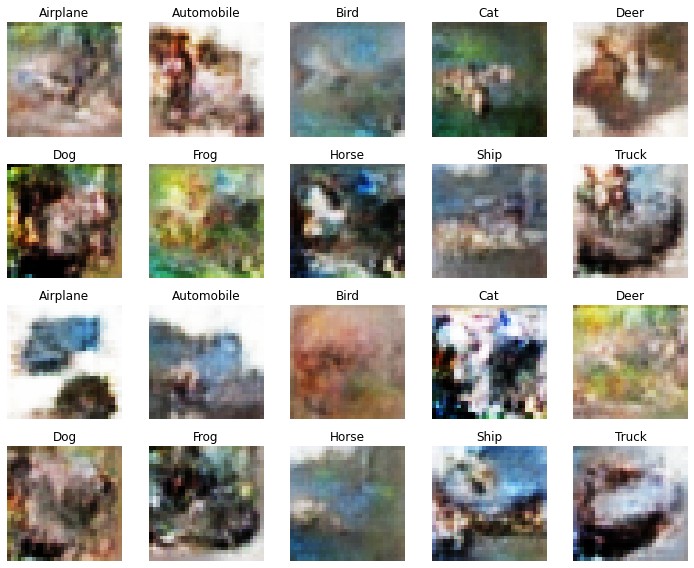

```
Generator Checkpoint - generator-epoch-10.h5
```

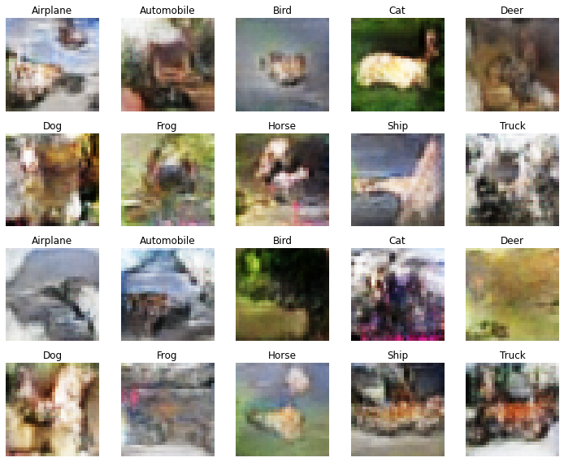

```
Generator Checkpoint - generator-epoch-15.h5
```

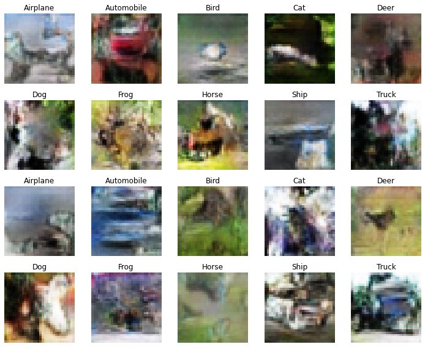

```
Generator Checkpoint - generator-epoch-20.h5
```

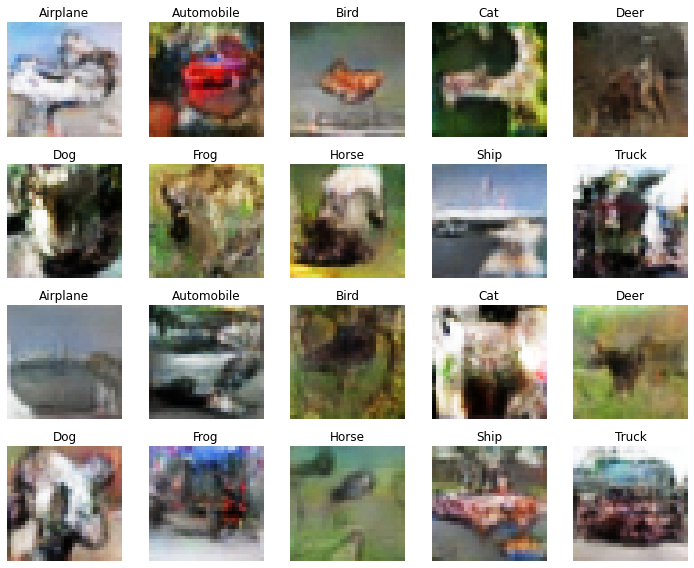

```
Generator Checkpoint - generator-epoch-25.h5
```

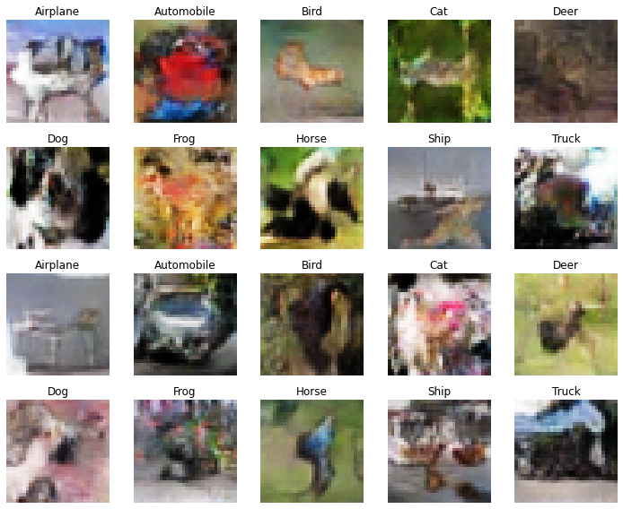

```
Generator Checkpoint - generator-epoch-30.h5
```

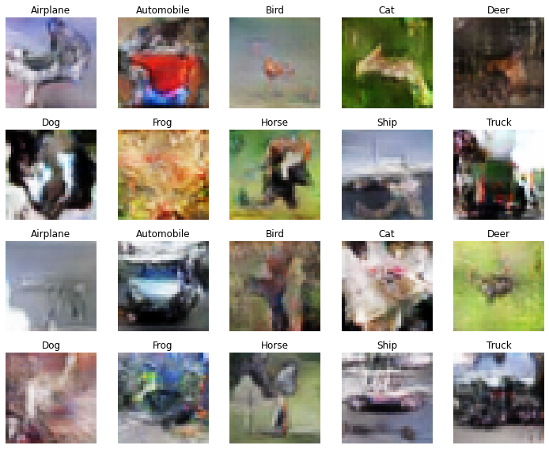

```
Generator Checkpoint - generator-epoch-35.h5
```

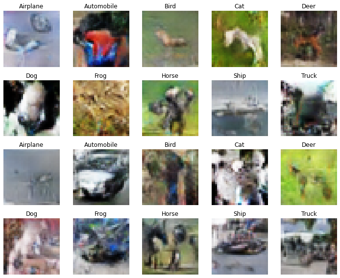

```
Generator Checkpoint - generator-epoch-40.h5
```

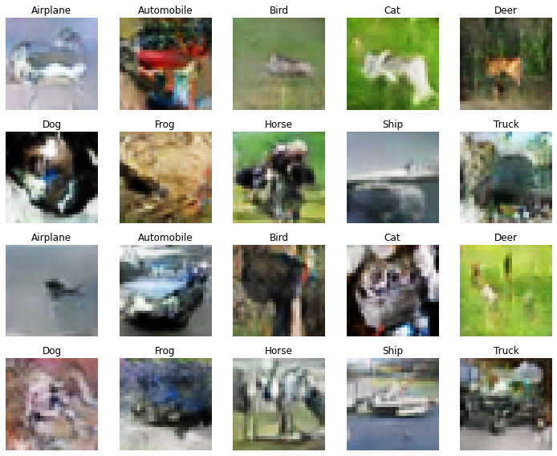

```
Generator Checkpoint - generator-epoch-45.h5
```

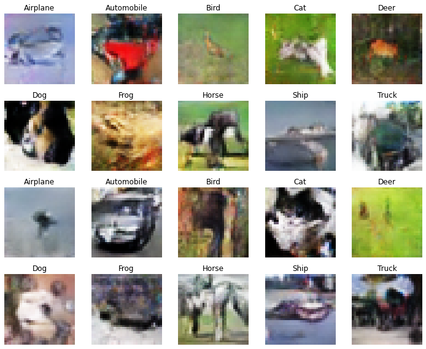

```
Generator Checkpoint - generator-epoch-50.h5
```

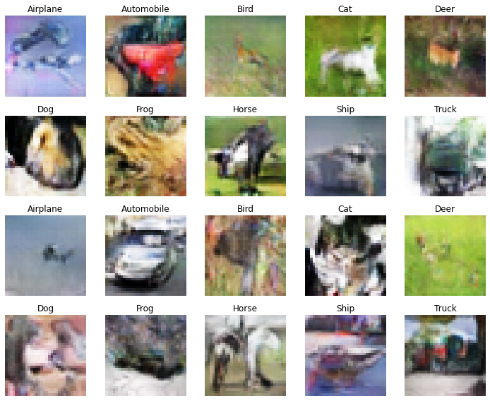

```
Generator Checkpoint - generator-epoch-55.h5
```

[9 more figures not shown]

```
Generator Checkpoint - generator-epoch-Full Train.h5
```

```python
# %%time
# Reseting Graph variables
tf.keras.backend.clear_session()
K.clear_session()

# Creating a cGAN class
cond_gan = ConditionalGAN(
    discriminator=discriminator,
    generator=generator,
    latent_dim=latent_dim
)
# Compiling with Optimizer and Loss Function
cond_gan.compile(
    d_optimizer=keras.optimizers.Adam(learning_rate=0.0002, beta_1=0.5),
    g_optimizer=keras.optimizers.Adam(learning_rate=0.0002, beta_1=0.5),
    disc_loss_fn=keras.losses.BinaryCrossentropy(),
    aux_loss_fn=keras.losses.CategoricalCrossentropy()
)

# Preparing the Dataset with `tf.data`
batch_size = 64
dataset = tf.data.Dataset.from_tensor_slices((x_train, y_train))
dataset = dataset.shuffle(buffer_size=1024).batch(batch_size, num_parallel_calls=tf.data.AUTOTUNE).prefetch(tf.data.AUTOTUNE)

# Starting the Train Process
hist = cond_gan.fit(dataset, epochs=100, use_multiprocessing=True, workers=16, callbacks=callbacks)
```

## GAN Evaluation

An important step to building our model would be evaluating it's performance. However, it is still an open problem till this date on the best way to evaluate a GAN.

### Problems with GAN Evaluation

In supervised learning, there are a common evaluation metrics like Accuracy and Mean Squared Error used, as there are training and testing sets together with labels provided. However in GAN, there are no "labels" provided, the main focus would be on the quality of the synthetic image.

Another way of evaluating GANs would be using their objective functions $V(D, G)$, however the objective functions of most GAN architectures (e.g. CGAN, WGAN) are likely to be different.

### Manual GAN Evaluation

The simplest method on evaluating Synthetic Image quality, using our eyes 👀. Despite being the simplest and the go-to method for evaluation, there are some disadvantages when dealing with the CIFAR-10 dataset.

1. Method of evaluation is subjective, there might be some bias by the reviewer.
2. CIFAR-10 dataset and generated images comes as a shape (32, 32, 3), the low resolution makes it hard to differentiate between classes.
3. Difficult to review large quantity of images.
4. I, Tan Yu Hoe, am medically diagnosed to be colour-blind. It is hard for me to differentiate between the pixels.

With these issues that I can think of, I will still display the images but this method would not be my default way of evaluation.

### Quantitative GAN Evaluation

Evaluating GAN on quantitative means refers to using a specific calculation of specific numerical scores, used to summarize the general quality of the images.

Most of the metrics I will be mention have a similar concept in mind, just different ways of evaluation - the main idea would be comparing high dimensional data distribution between the Original Images used for training and the Synthetic Images generated from the Generative model.

In order to inplement this, I will be using the following metrics for evaluation.

- **KL Divergence** (aka relative entropy) - measures the distance between two statistical probability
- **Fréchet Inception Distance** - compares distribution of generated images

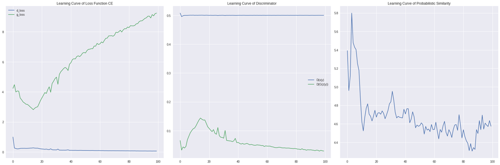

```python
# story history object into dataframe
hist_df = pd.DataFrame(hist.history)

# using pandas dataframe to plot out learning curve
with plt.style.context('seaborn'):
    fig, (ax1, ax2, ax3) = plt.subplots(1, 3, figsize=(24, 8), tight_layout=True)
    hist_df.loc[:, ["d_loss", 'g_loss']].plot(ax=ax1, title=r'Learning Curve of Loss Function CE')
    hist_df.loc[:, ['D(x|y)', 'D(G(z|y))']].plot(ax=ax2, title=r'Learning Curve of Discriminator')
    hist_df.loc[:,'KL Divergence'].plot(ax=ax3, title=r'Learning Curve of Probabilistic Similarity')
    plt.show()
```

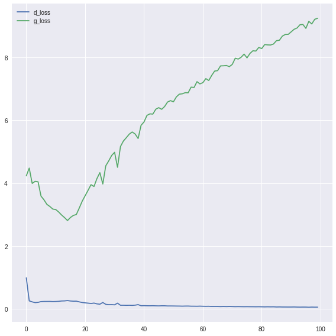

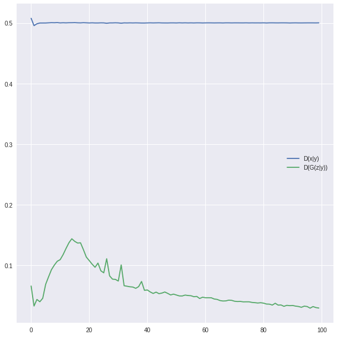

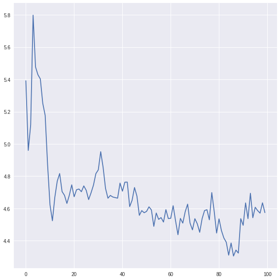

```python
# using pandas dataframe to plot out learning curve
with plt.style.context('seaborn'):
    for cols in [["d_loss", "g_loss"], ["D(x|y)", "D(G(z|y))"], "KL Divergence"]:
        fig, ax = plt.subplots(1, 1, figsize=(8, 8), tight_layout=True)
        hist_df.loc[:, cols].plot(ax=ax)
        plt.show()
```

```python
# Loading Weights for best Generator
saved_weights = 'generator-epoch-80.h5'
cond_gan.generator.load_weights(saved_weights)
cond_gan.generator.summary()
```

```
Model: "generator"
__________________________________________________________________________________________________
 Layer (type)                   Output Shape         Param #     Connected to
==================================================================================================
 Latent_Noise_Vector_z (InputLa  [(None, 128)]       0           []
 yer)

 Conditions_y (InputLayer)      [(None, 10)]         0           []

 concatenate (Concatenate)      (None, 138)          0           ['Latent_Noise_Vector_z[0][0]',
                                                                  'Conditions_y[0][0]']

 dense (Dense)                  (None, 2048)         284672      ['concatenate[0][0]']

 batch_normalization (BatchNorm  (None, 2048)        8192        ['dense[0][0]']
 alization)

 leaky_re_lu (LeakyReLU)        (None, 2048)         0           ['batch_normalization[0][0]']

 reshape (Reshape)              (None, 2, 2, 512)    0           ['leaky_re_lu[0][0]']

 Base_Generator (Sequential)    (None, 16, 16, 64)   2754752     ['reshape[0][0]']

 Output_Layer (Conv2DTranspose)  (None, 32, 32, 3)   3075        ['Base_Generator[0][0]']

==================================================================================================
Total params: 3,050,691
Trainable params: 3,045,699
Non-trainable params: 4,992
__________________________________________________________________________________________________
```

```
Latent Vector Dim: (10000, 128)	Generated Images Dim: (10000, 32, 32, 3)
```

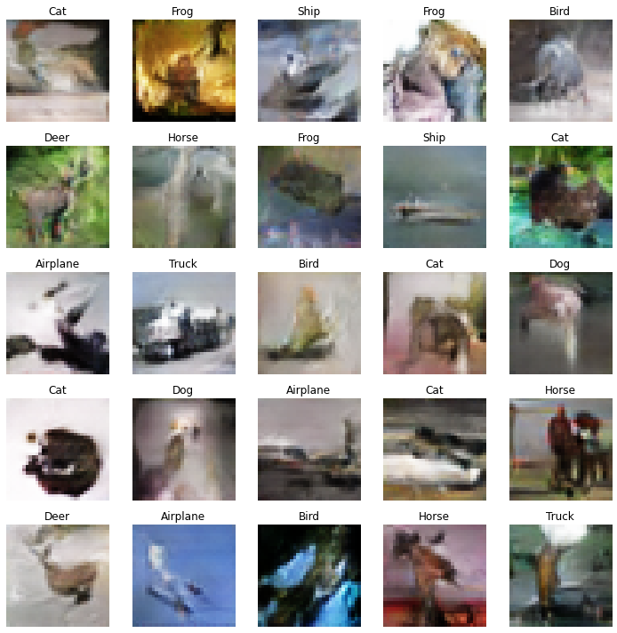

```python
n = 10000

# generating labels
labels = np.random.randint(low=0, high=10, size=n)
one_hot_labels = to_categorical(labels)

# Generating 1000 Synthetic Images
random_noise = tf.random.normal(shape=(n, latent_dim))

synthetic_images = cond_gan.generator.predict([random_noise, one_hot_labels])
print("Latent Vector Dim: {}\tGenerated Images Dim: {}".format(random_noise.shape, synthetic_images.shape))

# Scaling back to [0, 1]
synthetic_images -= -1
synthetic_images /= (1 - (-1))

# Display 25 randomly sampled images
fig = plt.figure(figsize=(10, 10), tight_layout=True)
for i in range(25):
    rand_idx = np.random.randint(0, len(synthetic_images))
    ax = fig.add_subplot(5, 5, i+1)
    ax.imshow(synthetic_images[rand_idx])
    ax.set_title(classes[labels[rand_idx]])
    ax.axis('off')
plt.show()
```

## Evaluation using Fréchet Inception Distance (FID)

> Frechet Inception Distance is a metric used to access the quality of images created by the generator by comparing the distribution of the generated images with the distribution of real images that were used to train the generator.

FID operates by using a Wasserstein metric to compare between two high dimensional matrices/tensors. These matrices are generated using an Embedding generated by a pre-trained Inception model. The mean and covariance are extracted from the embeddings to be then computed as a metric. The formal metric are described below:

$$FID = ||\mu - \mu_w||^2_2 + tr(C + C_w - 2(C C_w)^\frac{1}{2})$$

```python
# import relevant libraries to calculate FID
import numpy as np
from tensorflow.keras.applications.inception_v3 import InceptionV3, preprocess_input
from tensorflow.image import resize
from scipy.linalg import sqrtm
import math
from tqdm.notebook import tqdm
import tensorflow as tf
```

```python
class GAN_FID:
    def __init__(self, batch_size, latent_dim, sample_size, buffer_size):
        # setting Hyperparameters
        self.BATCH_SIZE = batch_size
        self.LATENT_DIM = latent_dim
        self.SAMPLE_SIZE = sample_size
        self.BUFFER_SIZE = buffer_size

        # setting Constants
        self.INCEPTION_SHAPE = (299, 299, 3)
        self.INCEPTION = InceptionV3(include_top=False, pooling='avg', input_shape=self.INCEPTION_SHAPE)
        self.AUTO = tf.data.AUTOTUNE

    # method to set generator and training data
    def fit(self, generator, train_data):
        # setting generative model and original data used for training
        self.GENERATOR = generator
        self.train_data = train_data

        # Preparing Real Images
        trainloader = tf.data.Dataset.from_tensor_slices((self.train_data))
        trainloader = (
            trainloader
            .shuffle(self.BUFFER_SIZE)
            .map(self.__resize_and_preprocess, num_parallel_calls=self.AUTO)
            .batch(self.BATCH_SIZE, num_parallel_calls=self.AUTO)
            .prefetch(self.AUTO)
        )
        self.trainloader = trainloader

        # Generate and prepare Synthetic Images (Fake)
        rand_labels = np.random.randint(low=0, high=10, size=self.SAMPLE_SIZE)
        rand_labels = to_categorical(rand_labels)
        noise = tf.random.normal([self.SAMPLE_SIZE, self.LATENT_DIM])

        generated_images = self.GENERATOR([noise, rand_labels])
        genloader = tf.data.Dataset.from_tensor_slices(generated_images)
        genloader = (
            genloader
            .map(self.__resize_and_preprocess, num_parallel_calls=self.AUTO)
            .batch(self.BATCH_SIZE, num_parallel_calls=self.AUTO)
            .prefetch(self.AUTO)
        )
        self.genloader = genloader

        # prepare embeddings
        count = math.ceil(self.SAMPLE_SIZE/self.BATCH_SIZE)

        ## compute embeddings for real images
        print("Computing Real Image Embeddings")
        self.real_image_embeddings = self.__compute_embeddings(self.trainloader, count)

        ## compute embeddings for generated images
        print("Computing Generated Image Embeddings")
        self.generated_image_embeddings = self.__compute_embeddings(self.genloader, count)
        assert self.real_image_embeddings.shape == self.generated_image_embeddings.shape, "Embeddings are not of the same size"
        print("Computed Embeddings\tReal Images Embedding Shape: {}\tGenerated Images Embedding Shape".format(
            self.real_image_embeddings.shape,
            self.generated_image_embeddings.shape
        ))

    # method to produce evaluation results
    @tf.autograph.experimental.do_not_convert
    def evaluate(self):
        # calculate Frechet Inception Distance
        fid = self.__calculate_fid(self.real_image_embeddings, self.generated_image_embeddings)
        print('The computed FID score is:', fid)

        return fid

    # method to generate embeddings from inception model
    def __compute_embeddings(self, dataloader, count):
        image_embeddings = []
        for _ in tqdm(range(count)):
            images = next(iter(dataloader))
            embeddings = self.INCEPTION.predict(images)
            image_embeddings.extend(embeddings)
        return np.array(image_embeddings)

    ## STATIC METHODS: these methods knows nothing about the class
    # static method to prepare the data before computing Inception Embeddings
    @staticmethod
    def __resize_and_preprocess(image):
        # image *= 255.0 # original image are scaled to [0, 1], scaling back to [0, 255]
        image -= -1
        image /= (1 - (-1))
        image *= 255.

        # .preprocess_input() expects an image of scale [0, 255]
        image = preprocess_input(image)
        # inception model expects an image of shape (None, 299, 299, 3)
        image = tf.image.resize(image, (299, 299), method='nearest')
        return image

    # static method to calculate frechet inception distance based on embeddings
    @staticmethod
    def __calculate_fid(real_embeddings, generated_embeddings):
        # calculate mean and covariance statistics
        mu1, sigma1 = real_embeddings.mean(axis=0), np.cov(real_embeddings, rowvar=False)
        mu2, sigma2 = generated_embeddings.mean(axis=0), np.cov(generated_embeddings, rowvar=False)
        # calculate sum squared difference between means
        ssdiff = np.sum((mu1 - mu2)**2.0)
        # calculate sqrt of product between cov
        covmean = sqrtm(sigma1.dot(sigma2))
        # check and correct imaginary numbers from sqrt
        if np.iscomplexobj(covmean):
            covmean = covmean.real
        # calculate score
        fid = ssdiff + np.trace(sigma1 + sigma2 - 2.0 * covmean)
        return fid
```

```python
%%time
fid_class = GAN_FID(batch_size=512, latent_dim=128, sample_size=10000, buffer_size=1024)
fid_class.fit(generator=cond_gan.generator, train_data=x_train)
fid_score = fid_class.evaluate()
```

```
Computing Real Image Embeddings
```

```
Computing Generated Image Embeddings
```

```
Computed Embeddings	Real Images Embedding Shape: (10240, 2048)	Generated Images Embedding Shape
The computed FID score is: 93.03919136892932
CPU times: user 3min 43s, sys: 19.2 s, total: 4min 2s
Wall time: 1min 48s
```

## Evaluation using ResNet32

In my opinion, using FID may not be entire accurate in terms of evaluating our synthetic images, given that the pretrained weights from Inception were trained on the ImageNet dataset. Another issue was that, I couldn't not tell which class is generated better than the other classes.

**ResNet32 Evaluation Result from ST1504 Deep Learning CA1**

| Architecture | Train Accuracy (%) | Test Accuracy (%) |
| --- | --- | --- |
| ResNet32 | 99.13 | 90.48 |

```python
# import module
from tensorflow.keras.models import load_model
from sklearn.metrics import confusion_matrix
from sklearn.metrics import classification_report

# load trained network
path = "/content/drive/MyDrive/DELE_CA2/model-best.h5"
resnet34 = load_model(path)

# Validating Model is accurate
train_loss, train_acc = resnet34.evaluate(x_train, np.argmax(y_train, axis=1))
test_loss, test_acc = resnet34.evaluate(x_test, np.argmax(y_test, axis=1))

#  Assert Statements
assert train_acc >= 0.9, "Train Accuracy falls below 90%"
assert test_acc >= 0.9, "Test Accuracy falls below 90%"
```

```python
%%time
# creating conditions and noise input
n_size = 1000
conditions = np.full(int(n_size/10), 0)
for i in range(9):
    conditions = np.concatenate([conditions, np.full(int(n_size/10), i+1)])
conditions = to_categorical(conditions)
latent_noise_vector = tf.random.normal(shape=(n_size, latent_dim))

# generate iamges
synthetic_imgs = cond_gan.generator.predict([latent_noise_vector, conditions])

# create predictions
predictions = resnet34.predict(synthetic_imgs)
```

```
CPU times: user 1.05 s, sys: 49.3 ms, total: 1.1 s
Wall time: 1.01 s
```

```python
# classification report
c_report = classification_report(np.argmax(conditions, axis=1), np.argmax(predictions, axis=1), target_names=classes.values())
print(c_report)
```

```
              precision    recall  f1-score   support

    Airplane       0.69      0.66      0.68       100
  Automobile       0.83      0.64      0.72       100
        Bird       0.61      0.40      0.48       100
         Cat       0.43      0.38      0.40       100
        Deer       0.51      0.76      0.61       100
         Dog       0.50      0.39      0.44       100
        Frog       0.60      0.88      0.72       100
       Horse       0.56      0.57      0.57       100
        Ship       0.70      0.78      0.74       100
       Truck       0.70      0.62      0.66       100

    accuracy                           0.61      1000
   macro avg       0.61      0.61      0.60      1000
weighted avg       0.61      0.61      0.60      1000
```

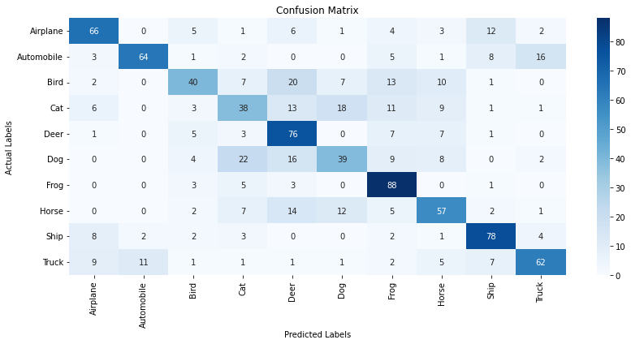

```python
# compute confusion matrix
cm = confusion_matrix(np.argmax(conditions, axis=1), np.argmax(predictions, axis=1))
plt.figure(figsize=(12, 6), tight_layout=True)
sns.heatmap(cm, cmap='Blues', annot=True, xticklabels=classes.values(), yticklabels=classes.values(), fmt='.3g')
plt.title('Confusion Matrix')
plt.xticks(rotation=90)
plt.xlabel('Predicted Labels')
plt.ylabel('Actual Labels')
plt.show()
```

# Save Generative Model

The final objective would be creating 1000 Synthetic Images, it would be my preference to have it done in another IPython Notebook.

```python
# summary information
cond_gan.generator.summary()

# saving as .hdf format
cond_gan.generator.save('ACGAN_Generator.h5')
assert os.path.exists('ACGAN_Generator.h5'), "ACGAN Generator does not exists"
```

```
Model: "generator"
__________________________________________________________________________________________________
 Layer (type)                   Output Shape         Param #     Connected to
==================================================================================================
 Latent_Noise_Vector_z (InputLa  [(None, 128)]       0           []
 yer)

 Conditions_y (InputLayer)      [(None, 10)]         0           []

 concatenate (Concatenate)      (None, 138)          0           ['Latent_Noise_Vector_z[0][0]',
                                                                  'Conditions_y[0][0]']

 dense (Dense)                  (None, 2048)         284672      ['concatenate[0][0]']

 batch_normalization (BatchNorm  (None, 2048)        8192        ['dense[0][0]']
 alization)

 leaky_re_lu (LeakyReLU)        (None, 2048)         0           ['batch_normalization[0][0]']

 reshape (Reshape)              (None, 2, 2, 512)    0           ['leaky_re_lu[0][0]']

 Base_Generator (Sequential)    (None, 16, 16, 64)   2754752     ['reshape[0][0]']

 Output_Layer (Conv2DTranspose)  (None, 32, 32, 3)   3075        ['Base_Generator[0][0]']

==================================================================================================
Total params: 3,050,691
Trainable params: 3,045,699
Non-trainable params: 4,992
__________________________________________________________________________________________________
WARNING:tensorflow:Compiled the loaded model, but the compiled metrics have yet to be built. `model.compile_metrics` will be empty until you train or evaluate the model.
```

```
WARNING:tensorflow:Compiled the loaded model, but the compiled metrics have yet to be built. `model.compile_metrics` will be empty until you train or evaluate the model.
```

# Conclusion / Further Improvements

**Improvements that could been done**

- Attempt to change loss function, e.g. Hinge Loss, Wasserstein Loss
- Label Smoothing
- Multiple Generator Update per Discriminator Update
- Differentiable Augmentation